# LTC palette previews for barcode trajectories

The same full counts and barcode order, with different colours

These previews use **every barcode** from chloramphenicol replicate 1 and no-antibiotic replicate 1. Band widths, barcode order, zero counts and the extracted-read denominator are identical across palette choices. The same barcode receives the same colour in the treatment and control within each choice. No barcodes are combined or filtered out.

All **32 LTC palettes by Loukas Theodosiou are built directly into barbac**. Choose one with `palette = "alger"`; no additional palette package is needed. These use the curated fills, with selected black and near-white colours omitted. We interpolate each selected palette end to end to obtain a colour for every barcode. Colour identifies a barcode; neither brightness nor hue represents its frequency. Many thin bands and neighbouring colours remain indistinguishable at screen resolution with this many lineages.

Open the main report with the plasma reference plots.

**alger**

**Treatment · replicate 1**

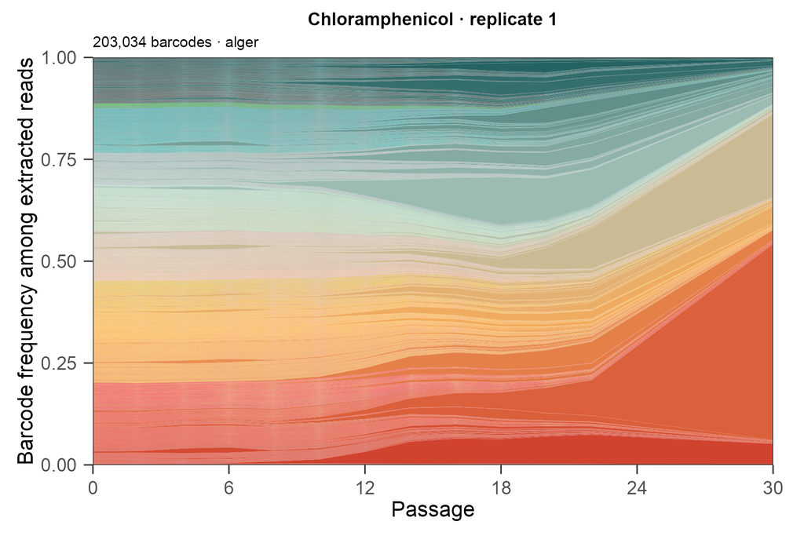

All treatment barcodes, alger

**Control · replicate 1**

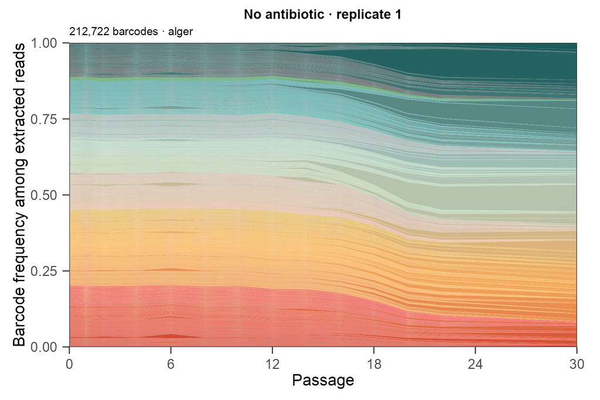

All control barcodes, alger

**dora**

**Treatment · replicate 1**

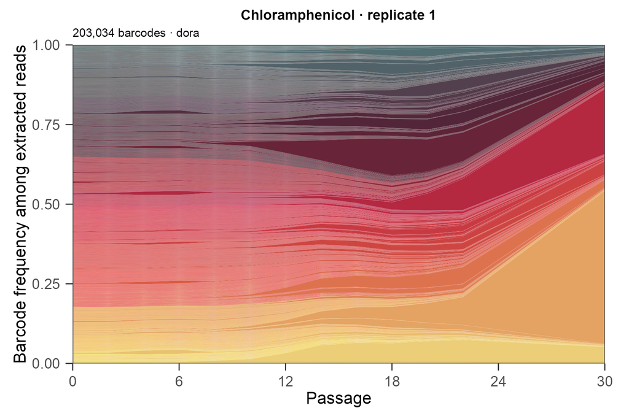

All treatment barcodes, dora

**Control · replicate 1**

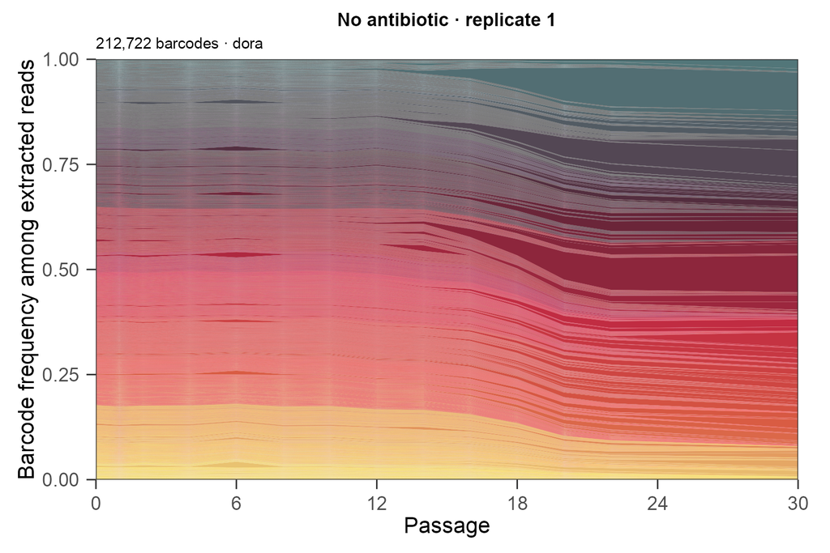

All control barcodes, dora

**casa_natal**

**Treatment · replicate 1**

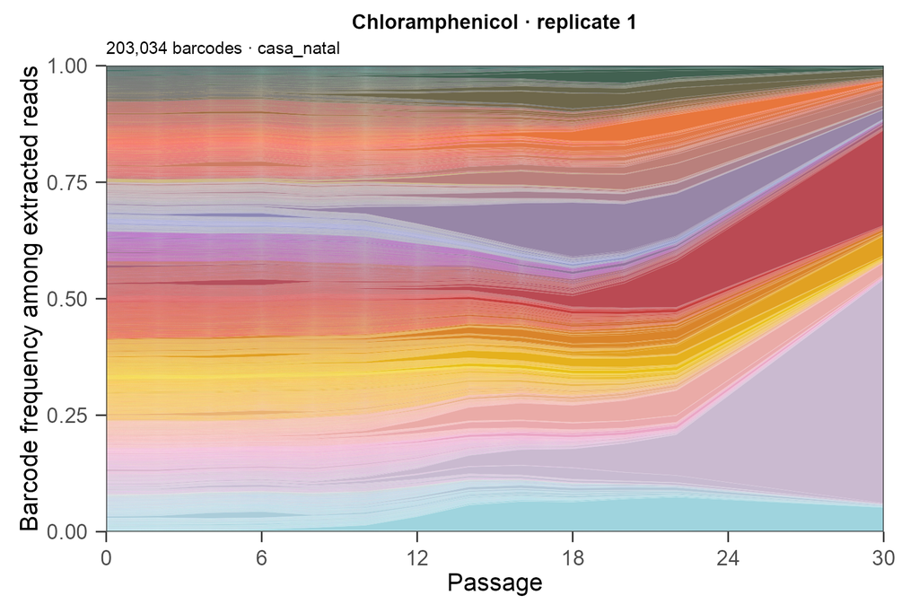

All treatment barcodes, casa_natal

**Control · replicate 1**

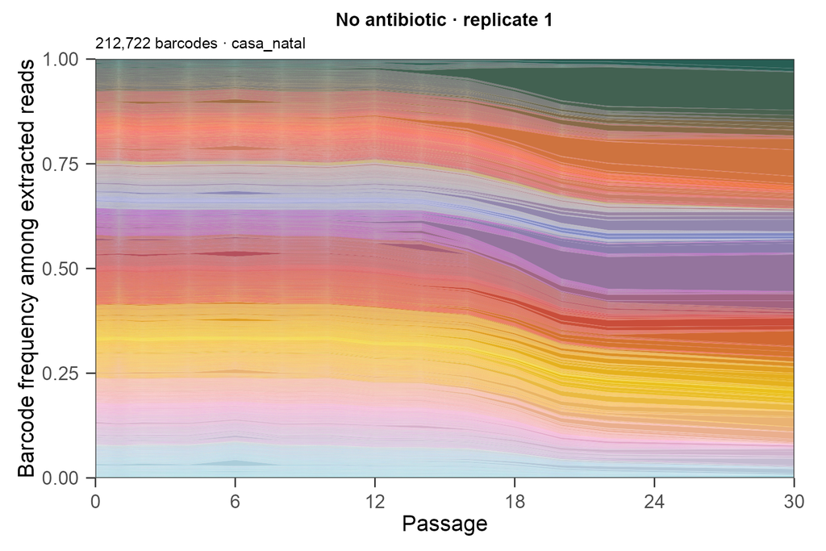

All control barcodes, casa_natal

## All 32 available palettes

The sheet below shows the interpolated options available in barbac. The `heatmap0`–`heatmap3` palettes are ordered ramps; their diverging shapes should not be interpreted as low/high barcode abundance when used for barcode identity.

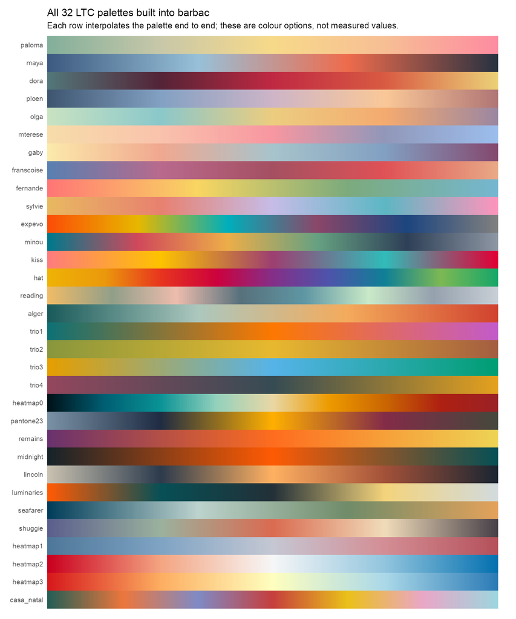

All 32 LTC palettes, interpolated end to end

## Use a palette with barbac

Pass the palette name directly:

```r
library(barbac)
barbac_ts_area(
  counts, min_total_count = 0, fill_missing = "zero",
  palette = "alger", show_legend = FALSE
)

names(barbac_palettes())  # list all 32 choices
```

For multiple populations, colours must be assigned over a shared set of barcode identifiers to keep the same barcode colour across panels, as in these previews:

```r
ids <- sort(unique(c(as.character(treatment$barcode), as.character(control$barcode))))
colours <- setNames(barbac_palette("alger", length(ids)), ids)

plot_population <- function(counts) {
  local_ids <- sort(unique(as.character(counts$barcode)))
  counts$barcode <- factor(counts$barcode, levels = local_ids)
  barbac_ts_area(counts, min_total_count = 0, fill_missing = "zero",
                 palette = unname(colours[local_ids]))
}
plot_population(treatment)
plot_population(control)
```

The existing treatment/control images are retained: barbac’s native palette vectors were checked to be identical to their original colour mappings. The R script, exact original and native palette snapshots, source hashes and numerical validation receipts are in `palette_preview.R` and `palette_preview/`. Click a plot for its full-size image when the accompanying folder is available.